# Reproducible Research: Peer Assessment 1

## Loading and preprocessing the data

The data is in csv format, so we simply use the read.csv function to read the data into a dataframe. We specify that there are headers, so that we get the proper column names. We can examine the resulting data frame with the *str* function.

```r
data <- read.csv("activity.csv", header = TRUE)
str(data)
```

```
## 'data.frame':    17568 obs. of  3 variables:
##  $ steps   : int  NA NA NA NA NA NA NA NA NA NA ...
##  $ date    : Factor w/ 61 levels "2012-10-01","2012-10-02",..: 1 1 1 1 1 1 1 1 1 1 ...
##  $ interval: int  0 5 10 15 20 25 30 35 40 45 ...
```

The resulting dataset contains two int and one factor variable and a total of 17568 observations. The *date* variable contains the date of the observations and was interpreted as a factor with 61 levels. We must be aware that there exist missing values (*NA*) within the *steps* data.

## What is mean total number of steps taken per day?

To get the sum of steps, seperated by day, we run the *tapply* function on the data, grouping it by the *date* column.

```r
stepsPerDay <- tapply(data$steps, data$date, sum, na.rm =TRUE)
```

We use the *hist* function to plot a histogram of average steps per day.

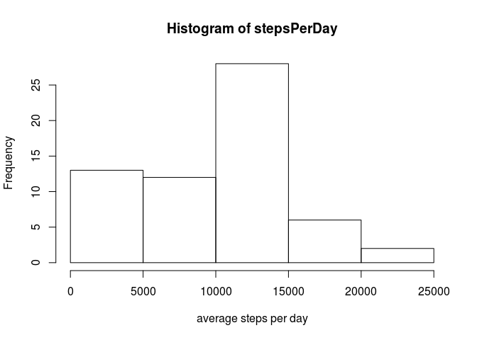

```r
hist(stepsPerDay, xlab="average steps per day")
```

### Mean

To calculate the mean of the data, we simply run:

```r
meanSteps <- mean(stepsPerDay)
meanSteps
```

```
## [1] 9354.23
```

and see that the mean steps taken each day is 9354.2295082.

### Median

The median is calculated simillarly by running:

```r
medianSteps <- median(stepsPerDay)
medianSteps
```

```
## [1] 10395
```

Which shows that the median is 10395.

## What is the average daily activity pattern?

First, we create an array of the averages of each 5-minute interval over all the obersvations. We then plot this data to get an overview.

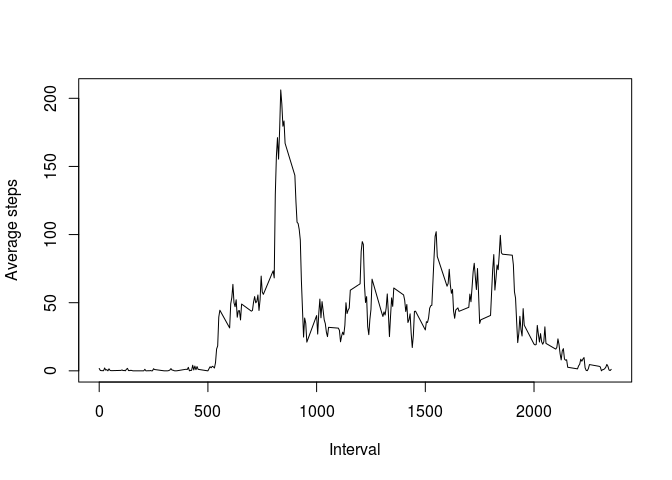

```r
intervalAvgs <- tapply(data$steps, data$interval, mean, na.rm = TRUE)
plot(names(intervalAvgs), intervalAvgs, type="l", xlab="Interval", ylab="Average steps")
```

We can see from the plot that the maximum value is somewhere between 0700 and 1000. To get the exact result, we use the *which.max* to get the index of the maximum and then look that value up.

```r
maxSteps <- intervalAvgs[which.max(intervalAvgs)]
maxSteps
```

```
##      835
## 206.1698
```

We see that the interval with the maximum average steps is the 835 interval with an average of 206.1698 steps.

## Imputing missing values

To count the number of missing values, we create a logical vector that is TRUE for NA values. We then sum it up, utilizing the fact that TRUE is represented as 1.

```r
missing <- sum(is.na(data$steps))
```

We can see that there are 2304 missing values, which is about 13.11% of the datapoints.

To impute *NA* values, we iterate over the rows of the data frame. When we encounter an *NA* value in the “steps” column, we look up this value from the *intervalAvgs* vector, using the name of the required interval.

```r
#Create a copy of the original data
correctedData <- data.frame(data)
for (i in 1:nrow(correctedData)) {
  if(is.na(correctedData[i, "steps"])) {
    #Get a String that represents the current interval
    interval <- as.character( correctedData[i, "interval"] )
    #lookup the average of that interval and replace the NA value
    correctedData[i, "steps"] <- intervalAvgs[ interval ]
  }
}
```

We calculate the daily sums of the corrected data and apply the mean and meadian functions to the result, just like before:

```r
correctedStepsPerDay <- tapply(correctedData$steps, correctedData$date, sum, na.rm = TRUE)
correctedMeanSteps <- mean(correctedStepsPerDay)
correctedMedianSteps <- median(correctedStepsPerDay)
```

The histogram of the corrected data looks like this:

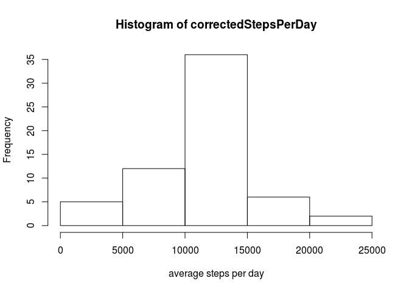

```r
hist(correctedStepsPerDay, xlab="average steps per day")
```

Let’s have a look at the original and corrected histograms side-by-side.

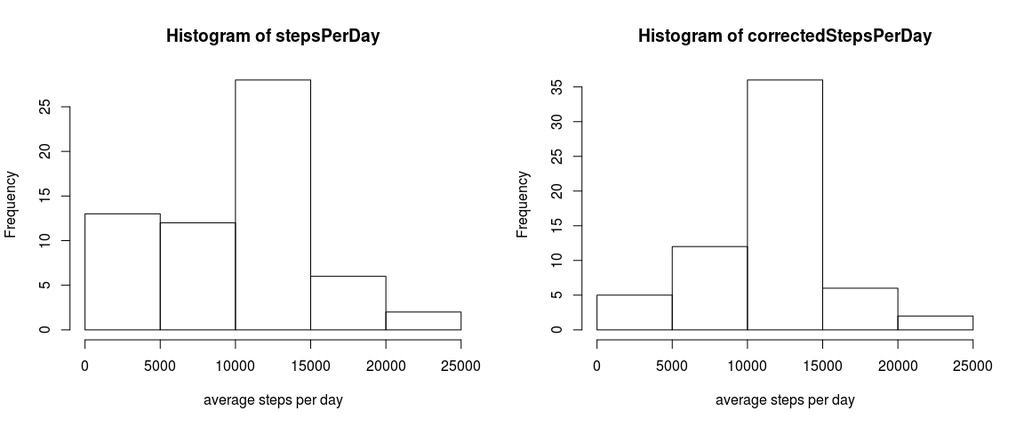

```r
par(mfrow=c(1, 2))
hist(stepsPerDay, xlab="average steps per day")
hist(correctedStepsPerDay, xlab="average steps per day")
```

We can see that the new histogram is more balanced and that the frequency for the lowest bin is now smaller. To compare the mean and median, we can combine the old and new data into a little comparison dataframe:

```r
comparison <- data.frame(c(meanSteps, correctedMeanSteps), c(medianSteps, correctedMedianSteps))
names(comparison) <- c("mean", "median")
row.names(comparison) <- c("old", "new")
comparison
```

```
##         mean   median
## old  9354.23 10395.00
## new 10766.19 10766.19
```

Here we can see that both the mean and the median have increased for the corrected data.

## Are there differences in activity patterns between weekdays and weekends?

To answer this question, we need to decide for every observation, if it was on a weekday or on the weekend and add this information to the dataframe.

```r
#Convertg the *date* column to the Date type
correctedData$date <- as.Date(correctedData$date)
#Create a vector of the days from the dates
days <- weekdays(correctedData$date)
#Create a character vector representing the type of day
daytype <- ifelse(days %in% c("Saturday", "Sunday"), "weekend", "weekday")
#Convert it to a factor and 'attach' it to the data
correctedData <- cbind(correctedData, daytype)
```

With the *daytype* column added to the corrected data, we can calculate the interval averages seperated by weekday and weekend. We do this by using the *aggregate* function. Aggregate works similar to *tapply*, but returns a dataframe instead. We just need to adjust the column names afterwards.

```r
byDaytypeData <- with(correctedData, aggregate(steps, list(interval, daytype), mean) )
names(byDaytypeData) <- c("interval", "daytype", "steps")
```

The *byDaytypeData* dataframe contains two observations for each interval, one with the weekday average and one with the weekend average. We use the lattice plotting system here to plot the average steps for each interval, seperated by the daytype factor variable.

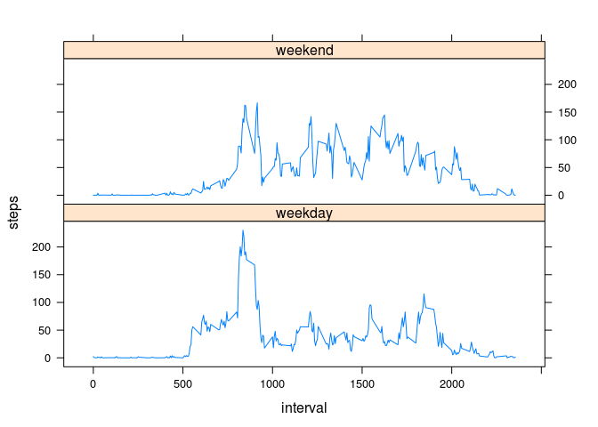

```r
library(lattice)
xyplot(steps ~ interval | daytype, data=byDaytypeData, type="l", layout=c(1,2))
```

The plots show that the spike in the morning on weekend dayss is not as distinct as on weekdays and that more steps are taken at noon and in the early afternoon.